# darkmix: steps

March 29, 2020

## Mixture Models for detection and characterization of Dark Matter halos

Authors: Lluís Hurtado-Gil, Michael A. Kuhn, Pablo Arnalte-Mur, Eric D. Feigelson, Vicent J. Martínez

In this notebook we reproduce the example presented in section 6 of publication Hurtado-Gil et al. in prep.

Requirements:

- R version 3.5.2 (2018-12-20) – “Eggshell Igloo” on Macintosh (or later)
- FFTW 3.3.8 (http://www.fftw.org)
- voro++ 0.4.6 (http://math.lbl.gov/voro++/)
- Compile C++ functions in Code folder as explained in the GitHub repository

Used R packages and functions:

- `spatstat` and `spatstat.utils`: `owin`, `pp3`, `unique`, `as.im`, `quadscheme`, `box3`, `variablesinformula` and `volume`
- `plotrix`: `draw.circle`
- `LaplacesDemon`: `Blocks` and `LaplacesDemon`
- `expint`: `gamma` and `gammainc`
- `misc3d`: `kde3d`
- `Base R`: multiple functions (in particular the function `optim`)

### Step 1 – Setup

Load the necessary functions and packages.

```r
source("Code/darkmix.R")
library(spatstat)
library(spatstat.utils)
library(expint)
library(plotrix)
library(misc3d)
library(LaplacesDemon)
```

Read the data set to create the point process object and its quadrature:

```r
data <- read.table("Data/datacat.txt")
minx <- 18; maxx <- 43;
miny <- 171; maxy <- 196;
minz <- 95; maxz <- 102;
clust <- pp3(x=data[,2],y=data[,3],z=data[,4], box3(xrange=c(minx,maxx), yrange=c(miny,maxy), zrange=c(minz,maxz)))
ntile <- c(50,50,14)
ntile <- c(100,100,28)
quad <- quad.3d(clust, ntile)
```

Declare a Finite Mixture Model of 10 cluster components plus background. Use Einasto profile for the clusters:

```r
k <- 10
v <- 5
param2 <-c(k+1,rep(c(einasto.model,v),k), const.model,0)
```

### Step 2 – Initial guess

Initialize the parameters vector and generate an initial guess of the clusters centers:

```r
param <- rep(0,k*(v+1))
cent <- centers(clust, h=0.3, ntile=c(25,25,7), k)
arg <- list(centers=cent[[1]], re=1, n=3, mix=1, back=-2)
param <- mixture.model(param, param2, output=c(), action.initial, arg)
param_df <- param2profile(param)
```

```
##       x     y     z re n mix
## 1  33.5 178.5  99.5  1 3   0
## 2  36.5 192.5  98.5  1 3   1
## 3  39.5 174.5  97.5  1 3   1
## 4  25.5 189.5  98.5  1 3   1
## 5  20.5 192.5 100.5  1 3   1
## 6  38.5 193.5  96.5  1 3   1
## 7  37.5 175.5  99.5  1 3   1
## 8  33.5 172.5 100.5  1 3   1
## 9  32.5 185.5  99.5  1 3   1
## 10 21.5 190.5  98.5  1 3   1
## Background mix: -2
```

The initial guess can be visualized:

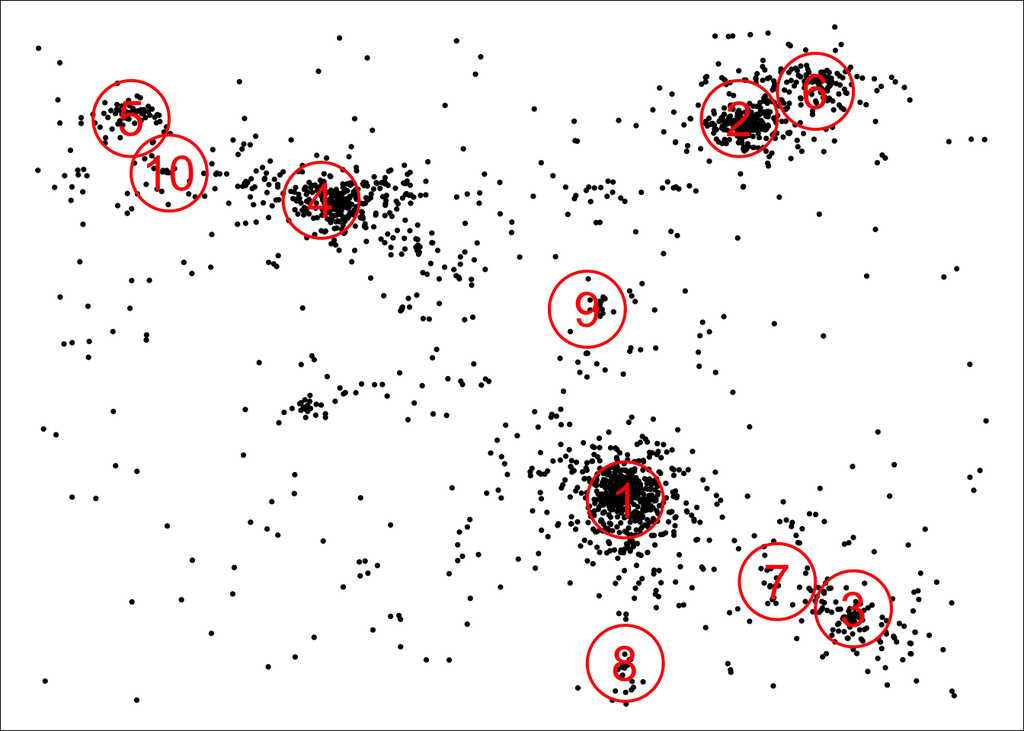

```r
arg = list(mar=c(0,0,0,0), clust=clust, col=2, pch=16,border=2, cex=0.5, cexl=2, lwd=2)
out <- mixture.model(param, param2, output = NULL, action.draw, arg)
```

### Step 3 – Likelihood maximization

Optimize the parameters via Nelder-Mead algorithm. Save the result.

```r
ocf <- optim(param, model.lik, param2=param2, model=mixture.model, clust=clust, quad=quad);
param <- ocf$par
```

For further model refinement use the `mask.freeze` functions.

```r
param <- mask.freeze(param, param2, mask.adjust_positions(k,v), clust, quad)
param <- mask.freeze(param, param2, mask.adjust_radii(k,v), clust, quad)
param <- mask.freeze(param, param2, mask.adjust_sersic(k,v), clust, quad)
param <- mask.freeze(param, param2, mask.adjust_mix(k,v), clust, quad)
```

The maximum likelihood, AIC and BIC can be calculated with

```r
aic_bic <- AIC.BIC(param, param2, clust, quad)
```

```
## [1] "Maximum likelihood: 1259.97151973845"
## [1] "AIC: -2399.94303947691"
## [1] "BIC: -2061.50680989329"
```

However, the resulting parameters are still far from the best fit. Repeat the previous steps to obtain better results. In the following steps we present the results with the already obtained fit.

Visiualize again to see the new model:

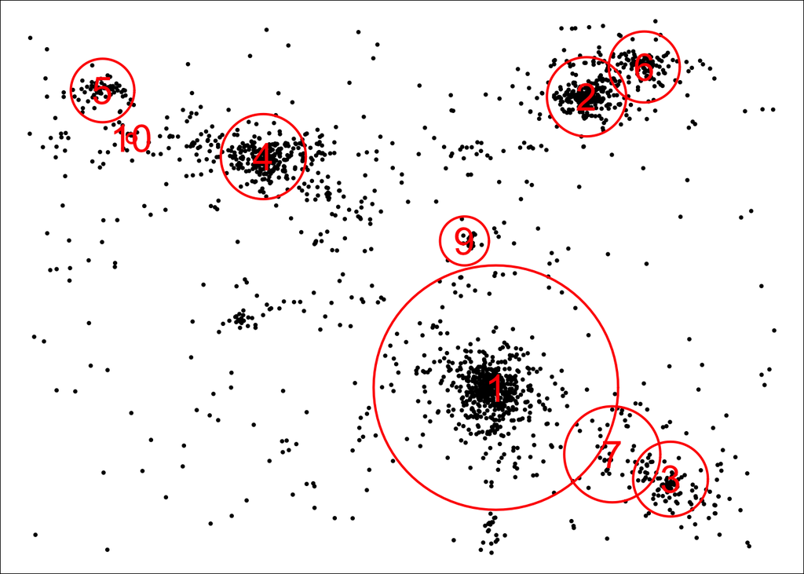

```r
arg = list(mar=c(0,0,0,0), clust=clust, col=2, pch=16,border=2, cex=0.5, cexl=2, lwd=2)
out <- mixture.model(param, param2, output = NULL, action.draw,arg)
```

If the model is trusted, use it estimate the number of particles per cluster:

```r
arg <- list(clust=clust, quad=quad)
pop <- mixture.model(param,param2,output=c(), action.pop, arg)
pop
```

```
##  [1] 756.75799586 370.82659427 134.40499418 414.63596087  86.67630725
##  [6] 116.64618730  14.27932726   0.00000000  34.88250702   0.08185145
## [11] 151.80827454
```

### Step 4 – Goodness of fit

The goodness of fit can be evaluated with function `goodness` (calculation might take several minutes).

```r
goodness(param, param2, clust, quad, ntile, residual.type="raw", bandwidth=1)
```

```
## [1] 0.9244465
```

The different kernel density fields can be generated at once. By order of appearance: absolute residuals, relative residuals, data density field and model density field.

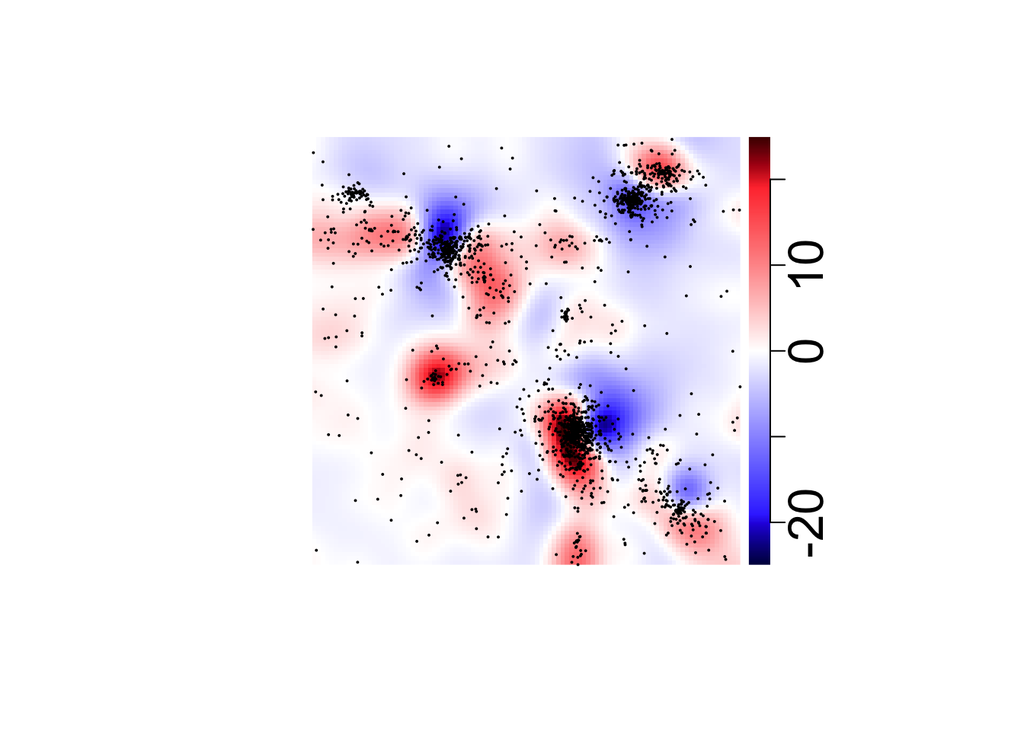

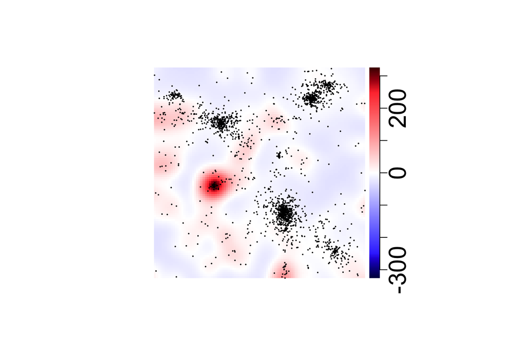

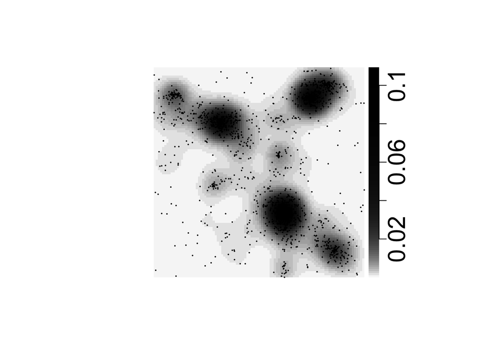

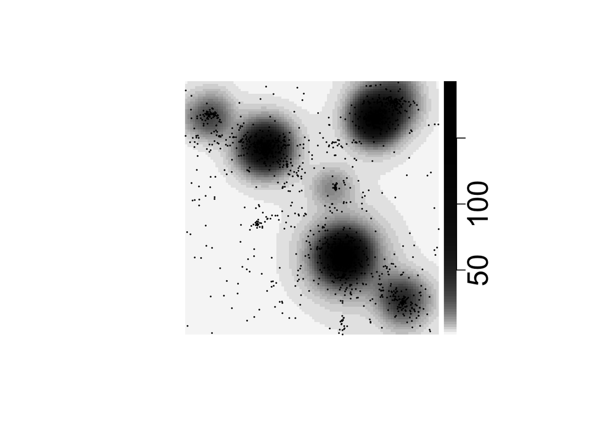

```r
maps <- c("s", "e", "d", "m")
plot.mm3d(param, param2, clust, quad, residual.type="raw", bandwidth=1, maps=maps, fast=TRUE, col.point=1, scale="log", proj.var="Z", print=FALSE, print.data=TRUE, w=880, h=880)
```

The membership of each particle to the clusters can be obtained and plotted as follows:

```r
classification <- membership(param, param2, mixture.model, clust, threshold=0.3, print=FALSE)
```

[figure not shown]

Another possibility is to generate new samples reproducing the original data set (if a component has very few particles warnings might appear).

```r
window <- clust$domain
num_particles <- data.frame(table(classification[[1]]$class))
data_generated <- gen.pattern(param, param2, num_particles, window, scl=4)
```

Visualize the new sample with

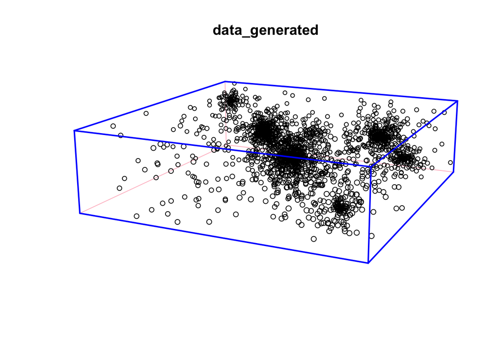

```r
plot(data_generated)
```

We can visualize as well the empirical density profile as centered in a given component together with the full model and the single component estimations. For example, for component 4:

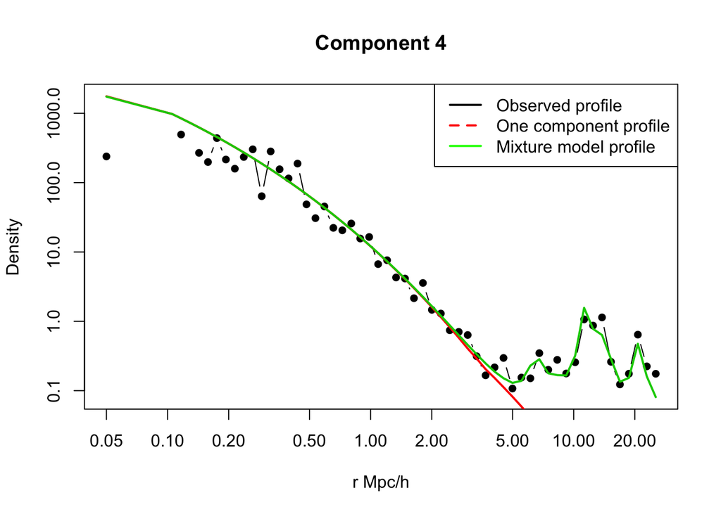

```r
comp <- 4
profiles <- plot.profile(param, param2, clust, comp, xlim=c(0.1,40), nbin=60, flag.legend=TRUE)
```

### Step 5 – New model

Although we do not execute these functions here, we include the necessary calls for the MCMC routines:

```r
MyData <- ready.mcmc(clust,quad,param2,rbord=0.5)
method="twalk"
Fit <- run.ld(param,MyData,method,iter=10000)
param <- Fit$Posterior2
```